# General Introduction

## The consequences of climate change

Understanding the underlying mechanisms by which climate change is affecting marine organisms is an area of increasing concern to marine ecophysiologists worldwide (Dahlhoff 2004; Helmuth, Kingsolver, and Carrington 2005; Chown et al. 2010; Somero, Lockwood, and Tomanek 2017). As anthropogenic activities transform the ocean’s natural systems, their impacts will continue to cascade through the marine biosphere across temporal and spatial scales, from organisms to whole ecosystems (Munday et al. 2013; Gattuso et al. 2015).

It is now known that the increased concentration of atmospheric carbon dioxide (pCO2) from human activity contributes to rising temperatures globally (IPCC 2014), and the ocean acts as a climate buffer that absorbs 25% to 40% of CO2 emissions and 90% of heat, changing its chemistry and physics (Fletcher et al. 2006; IPCC 2014; Gattuso et al. 2015). Consequently, alterations in temperature (Mann et al. 2017; Wijffels et al. 2016), carbonate chemistry (Caldeira and Wickett 2003; Hoegh-Guldberg et al. 2017), oxygen concentration (Schmidtko, Stramma, and Visbeck 2017; Chu and Gale 2017) and light availability (Gattuso et al. 2006) are causing wide-ranging impacts on oceanic primary productivity (Behrenfeld et al. 2016), trophic interactions (Ullah et al. 2018), and species distributions (García Molinos et al. 2015; Brown et al. 2016; Sommer et al. 2018).

Without mitigation measures, global pCO2 levels will continue to increase from the current 410 ppm to 985 ppm (IPCC 2013), and average global temperatures will likely exceed +2°C relative to 1986–2005 by the end of this century (RCP8.5 scenario, Riahi et al. 2011; IPCC 2014). These changes will likely further amplify the ecological impacts currently observed on both our natural and human ecosystems globally.

## Using physiology to understand tolerances to environmental change

While the broad consequences of ocean change are well-documented in the literature, the challenge now is to tease apart the underlying casual mechanisms that drive those changes to understand the linkages between ecosystem effects and the processes that occur at the level of organism and cell (Pörtner 2002; Somero 2005, 2012). This will allow us to accurately predict which species within ecosystems are most vulnerable to the risks associated with current and future scenarios of ocean change (Munday et al. 2013; Sinclair et al. 2016; Verberk et al. 2016). Doing so is not a trivial undertaking, owing to the diverse and multi-stressor nature of environmental change (Byrne and Przeslawski 2013; Boyd and Brown 2015) and intrinsic phenotypic flexibility (i.e. phenotypic plasticity) that individuals possess as they modify their growth, development and behaviour in response to environmental cues (Forsman 2015; Murren et al. 2015).

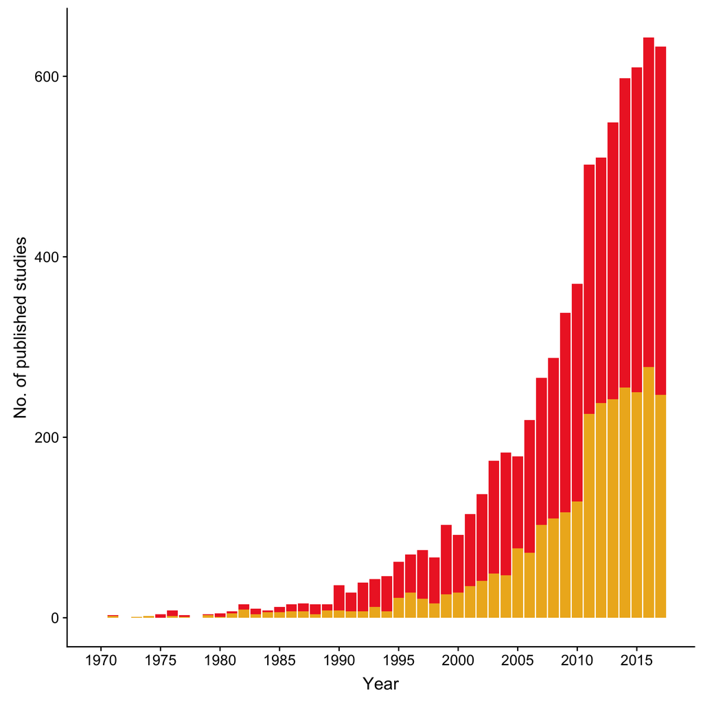